# Gamma

Wenhui Wu

2022-10-25

## Introduction

近年来，基于退化的可靠性技术在模型、方法和应用等方面得到快速发展。其中，在**基于退化的可靠性模型**方面，以随机过程理论为基础，根据工程需要，并考虑模型的简明性、实用性和适用性，已经提出了多种类型的模型，包括：

1. 退化轨道模型（如 Paris 模型、随机斜率/截距模型、幂律模型、反应论模型）
2. 基于 Wiener 过程的模型
3. 基于 Gamma 过程的模型
4. 累积损伤模型(主要是基于混合 Poisson 过程的模型）
5. 更为一般的纯跳过程模型（如Levy.过程模利）和扩散过程模型（如随机微分方程模型）等。

在基于退化的可靠性建模方法，以数理统计理论为基础，针对模型和退化数据的类型，研究**矩估计、极大似估计及 EM 算法、Bayes 估计及 MCMC算法、基于滤波的状态估计方法**，以及**非参数和半参数方法**等，解决模型辨识和修正问题;

采用**似然比检验、Bayes 因子分析**等方法进行模型验证;

采用**均方误差（MSE）、Akaike 信息准则(AIC)、Bayes 信息准则(BIC)、偏差信息准则(DIC)**等进行模型优良性检验。

在基于退化的可靠性技术应用方面，针对**机械零部件（如轴承、润滑系统）、半导体器件（如功率MOS器件）、机电部件（如感应电动机）、光电器件(如太阳电池、激光器、LED)、电子器件（如电容、蓄电池）**等的退化失效过程，开展**退化过程建模、可靠性评估、剩余寿命预测、可靠性试验设计**：特别是加速退化试验方案设计的研究。

## Gamma退化过程模型

Gamma 过程描述的退化过程是严格单调非负的，并且Gamma 过程是纯跳过程，其样本路径不连续，既可描述连续的微小冲击导致的缓慢退化，也可以描述大的冲击导致的大的损伤。

### 似然函数

假设共有 $\mathrm{n}$ 个样品进行性能退化试验. 对于样品 $i$, 初始时刻 $t_0$ 性 能退化量为 $X_{i 0}=0$, 在时刻 $t_1, \cdots, t_{m_i}$ 测量产品的性能退化量, 得到 其测量值为 $X_{i 1}, \cdots, X_{i m_i}$. 记 $\Delta x_{i j}=X_{i j}-X_{i(j-1)}$ 是样品 $i$ 在时刻 $t_{j-1}$ 和 $t_j$ 之间的性能退化量, 由 Gamma 过程的独立增量性得到$\Delta X(t) \sim Ga(\alpha \Delta t_{ij},\beta)$。则似然函数为

$$l(\alpha, \beta)=\sum_{i=1}^n\left(\sum_{j=1}^{m_i}\left(\alpha \Delta
t_{i j}-1\right) \ln \Delta x_{i j}-\alpha t_{i m_i} \ln
\beta-\sum_{j=1}^{m_i} \ln \Gamma\left(\alpha \Delta t_{i
j}\right)-\frac{x_{i m_i}}{\beta}\right)$$

### 产品寿命

因为Gamma 过程的退化是单调递增的，即$X(t) \sim Ga(\alpha t,\beta)$ ,因此**产品寿命**的分布可以通过退化量的转变关系获得。当给定产品退化失效阈值 $\ell$ 时，产品寿命 $T$ 的CDF和PDF为

$$\begin{aligned}
\mathrm{F}_{\mathrm{T}}(t) &=\mathrm{P}(\mathrm{T} \leqslant
\mathrm{t})=\mathrm{P}(\mathrm{X}(\mathrm{t}) \geqslant \ell) \\
&=\int_{\ell}^{\infty} \frac{1}{\Gamma(\alpha \mathrm{t})
\beta^{\alpha \mathrm{t}}} \mathrm{x}^{\alpha \mathrm{t}-1}
\mathrm{e}^{-\frac{\mathrm{x}}{\beta}} \mathrm{dx} \\
&=\frac{1}{\Gamma(\alpha \mathrm{t})}
\int_{\frac{\ell}{\beta}}^{\infty} \xi^{\alpha \mathrm{t}-1}
\mathrm{e}^{-\xi} \mathrm{d} \xi ,\\
\mathrm{f}_{\mathrm{T}}(t) &=\frac{\mathrm{d}}{\mathrm{dt}}
\frac{\Gamma(\alpha \mathrm{t}, 1 / \beta)}{\Gamma(\alpha \mathrm{t})}
\\
&=\frac{\alpha}{\Gamma(\alpha \mathrm{t})} \int_0^{\nu /
\beta}\left[\ln (\xi)-\frac{\Gamma^{\prime}(\alpha
\mathrm{t})}{\Gamma(\alpha \mathrm{t})}\right] \xi^{\alpha \mathrm{t}-1}
\mathrm{e}^{-\xi} \mathrm{d} \xi.
\end{aligned}$$

由于$\mathrm{f}_{\mathrm{T}}(\mathrm{t})$ 相当复杂，因此一般用B-S分布来逼近：

$$\mathrm{F}(t ;
\ell)=\Phi\left[\frac{1}{\mathrm{v}}\left(\sqrt{\frac{\mathrm{t}}{\mathrm{u}}}-\sqrt{\frac{\mathrm{u}}{\mathrm{t}}}\right)\right],
\quad \mathrm{t}>0$$
其中, $\Phi(\cdot)$ 为标准正态分布, $v=\sqrt{\frac{\beta}{\ell}}, u=\frac{\ell}{\beta \alpha}$. 相应的 PDF 为
$$\mathrm{f}(t ; \ell)=\frac{1}{2 \sqrt{2 \pi}
\mathrm{uv}}\left[\left(\frac{\mathrm{u}}{\mathrm{t}}\right)^{\frac{1}{2}}+\left(\frac{\mathrm{u}}{\mathrm{t}}\right)^{\frac{3}{2}}\right]
\exp \left[-\frac{1}{2
\mathrm{v}^2}\left(\frac{\mathrm{t}}{\mathrm{u}}-2+\frac{\mathrm{u}}{\mathrm{t}}\right)\right],
\mathrm{t}>0$$

### 剩余寿命

根据Gamma 过程的增量独立性，可以得到剩余寿命的分布
$$\begin{aligned}
\mathrm{F}(t \mid s) &=\mathrm{P}\left(\mathrm{T} \leqslant t \mid
\mathrm{X}(s)=\mathrm{x}_{s}\right) \\
&=\mathrm{P}\left(X(t)-X(s) \geqslant \ell-x_{s}\right) \\
&=\frac{\Gamma\left(\alpha(t-s),\left(\ell-x_{s}\right) /
\beta\right)}{\Gamma(\alpha(t-s))} .
\end{aligned}$$
这与将失效阈值由 $\ell$ 变为 $\ell-{x_s}$ 、时间 $t$ 变为 $t-s$ 情形的寿命分 布是一样的. 因此, 在给定当前状态情况下, 可以按照类似的途径更新剩余寿命.

```r
library(ggplot2)
library(tidyverse)
library(viridis)
library(dplyr)
```

### 数据模拟产生

```r
# 数据模拟产生
sim_dat = function(group = 6, t = 1:200, para = c(4,2)){
  # para 指 alpha,beta
  # epoch 指测量次数， group 指组数
  delta_t = diff(t)
  epoch = length(delta_t)
  dat = dat_unit = matrix(NA,epoch,group+1)
  dat[,1] = dat_unit[,1] = seq(1,epoch)
  # dat_unit = numeric()
  for(i in 1:group){
    for(j in 1:epoch) {
      dat_unit[j,i+1] = rgamma(1,shape = para[1]*delta_t[j],scale = para[2])
      dat[,i+1] = cumsum(dat_unit[,i+1])
    }
  }
  dat = data.frame(dat)
  dat1 = rbind(rep(0,group+1),dat) # 加入初始值绘制点
  colnames(dat1) = c("Time",paste(1:group,sep=''))

  dat_unit = data.frame(dat_unit)
  dat_unit1 = rbind(rep(0,group+1),dat_unit) # 加入初始值绘制点
  colnames(dat_unit1) = c("Time",paste(1:group,sep=''))

  return(list(dat1,dat_unit1)) #dat1是退化量,data_unit1是退化增量
}
```

#### 绘制退化路径图

```r
# 绘制退化路径图
plot_path = function(data = dat1){
    # 画图
  p = data %>% pivot_longer(paste(1:group),
                       names_to = "Group",
                       values_to = "y") %>%
    ggplot(aes(Time,y,color = Group)) +
    geom_line() +
    scale_color_viridis(discrete = T) +
    ylab("Degradation") #+
    #theme_bw() +
    #theme(panel.grid = element_blank())
  print(p)
}
```

```r
group = 6
t = 1:200
para = c(4,2)
dat = sim_dat(group = group, t = t, para = para)
knitr::kable(head(dat[[1]])) #print table
```

| Time | 1 | 2 | 3 | 4 | 5 | 6 |
| --- | --- | --- | --- | --- | --- | --- |
| 0 | 0.000000 | 0.000000 | 0.000000 | 0.00000 | 0.000000 | 0.000000 |
| 1 | 6.196803 | 9.067097 | 9.374138 | 17.46283 | 5.501217 | 6.984545 |
| 2 | 11.124809 | 18.120671 | 11.936361 | 31.77836 | 24.148121 | 12.769499 |
| 3 | 14.030780 | 26.196160 | 24.285645 | 36.41090 | 29.034672 | 17.702602 |
| 4 | 21.953972 | 39.419799 | 29.228167 | 45.59032 | 34.773494 | 20.474151 |
| 5 | 29.101200 | 45.132247 | 38.495665 | 54.87558 | 46.517989 | 27.640405 |

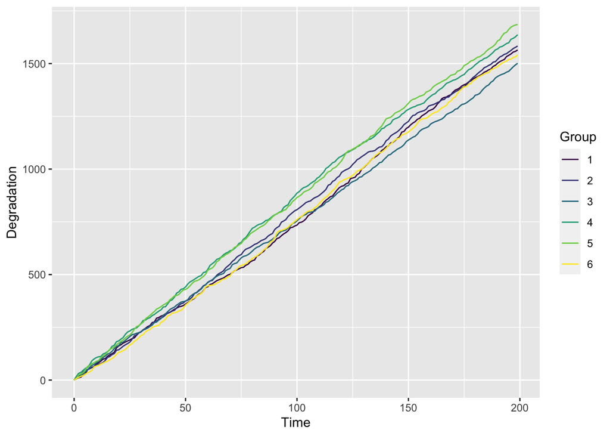

```r
plot_path(dat[[1]]) #print path plot
```

### 参数估计

#### 矩估计

```r
gamma_moment = function(data_unit, group , t ){

  # 每组测量次数相同
  delta_t = diff(t)
  M = group*max(t)
  Rij = data_unit/delta_t
  Rbar = sum(Rij)/M
  MSR2 = sum((Rij-Rbar)^2)
  tt = group*sum(1/delta_t)
  moment_alp = Rbar^2*tt/MSR2
  moment_beta = MSR2/(tt*Rbar)

  moment_par = c(moment_alp,moment_beta)
  return(moment_par)

}
# 这里算出来beta的矩估计跟真值差距很大
# 注意如果用模拟数据产生的话，只保留增量数据,也要去掉第一行的0
# ？ 前面加上这么多只是为了画图好看，是不是可以删掉这些东西
increment = dat[[2]]
increment = increment[-1,2:7]
degradation = dat[[1]]
degradation = degradation[-1,2:7]

moment_par = gamma_moment(data_unit = increment, group = 6, t = 1:200)
moment_par
```

```
## [1] 4.233404 1.872493
```

#### 极大似然估计

```r
library(BB)

gamma_alpmle = function(x, data_unit, data, t){
    #x is alpha
    delta_t = diff(t)
    l = sum(delta_t*log(data_unit))-sum(t*log(data/(x*t)))-sum(delta_t*digamma(x*delta_t))
    return(l)
}

startx = 1
mle_re = dfsane(startx,gamma_alpmle,data_unit = increment, data = degradation, t = 1:200,control=list(maxit=2500,trace = FALSE))

mle_re
```

```
## $par
## [1] 7.197344
##
## $residual
## [1] 2.786055e-08
##
## $fn.reduction
## [1] 235197.3
##
## $feval
## [1] 10
##
## $iter
## [1] 9
##
## $convergence
## [1] 0
##
## $message
## [1] "Successful convergence"
```

```r
mle_alp = mle_re$par
mle_beta = sum(increment)/(mle_alp*group*max(t))
mle_par = c(mle_alp,mle_beta)

mle_par
```

```
## [1] 7.197344 1.101381
```

```r
# mle_re = uniroot(gamma_alpmle, data_unit = increment, data = degradation, t = 1:200, lower = 1, upper = 100, tol = 1e-15, maxiter = 10000)
#
# mle_alp = mle_re$root
# mle_beta = sum(increment)/(mle_alp*group*max(t))
# mle_par = c(mle_alp,mle_beta)
```

```r
## 可靠度计算
gamma_R = function(t, threshold,par){
  alp = par[1]
  beta = par[2]
  v = sqrt(beta/threshold)
  u = threshold/(alp*beta)
  R = 1-pnorm((sqrt(t/u)-sqrt(u/t))/v)
  return(R)
}
gamma_R(t = 70, threshold = 150,par = mle_par)
```

```
## [1] 0
```

```r
# plot(gamma_R(t = 1:300, threshold = 150,par = mle_par),type = "l")
```

#### 案例分析

导入数据，数据来源于[NASA Ames Prognostics Center of Excellence (PCoE)](https://c3.ndc.nasa.gov/dashlink/resources/133/)，但是找不到数据下载。最后是通过 [Github](https://github.com/psanabriaUC/BatteryDatasetImplementation) 获得。

```r
liion_data = read.csv("dataset/li-ion_battery_aging.csv")
head(liion_data)
```

```
##   Voltage_measured Current_measured Temperature_measured Current_charge
## 1         3.974871        -2.012528             24.38909         1.9982
## 2         3.951717        -2.013979             24.54475         1.9982
## 3         3.934352        -2.011144             24.73139         1.9982
## 4         3.920058        -2.013007             24.90982         1.9982
## 5         3.907904        -2.014400             25.10588         1.9982
## 6         3.897036        -2.011603             25.31702         1.9982
##   Voltage_charge    Time Capacity id_cycle      type ambient_temperature time
## 1          3.062  35.703 1.856487        1 discharge                  24 2008
## 2          3.030  53.781 1.856487        1 discharge                  24 2008
## 3          3.011  71.922 1.856487        1 discharge                  24 2008
## 4          2.991  90.094 1.856487        1 discharge                  24 2008
## 5          2.977 108.281 1.856487        1 discharge                  24 2008
## 6          2.967 126.453 1.856487        1 discharge                  24 2008
##   Battery
## 1   B0005
## 2   B0005
## 3   B0005
## 4   B0005
## 5   B0005
## 6   B0005
```

该数据是 NASA Ames Prognostics Center of Fxcellence (PCoF）对商用锂离子 18650 电池进行充、放电试验获得的一组蓄电池容量变化数据。试验过程中，锂离子在室温下 经历 3 种不同的运行剖面，即**充电**、**放电**和**测量 EIS**。

充电是以**恒流模**式(CC)进行，在 1.5A 电流下直到电池电压达到4.2V，然后以**恒压模式**(CV)继续充电直到电流降到 20mA。

放电也以恒流模式进行，放电电流为2A，直到电池电压降低到2.7V。

重复充电和放电降导致蓄电池老化。对应的四个产品电池容量变化如下图所示：

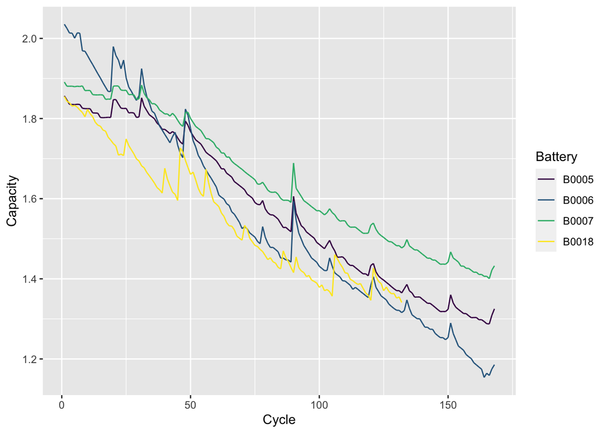

```r
liion_data %>%
  ggplot(aes(id_cycle,Capacity,color = Battery)) +
  geom_line() +
  scale_color_viridis(discrete = T) +
  xlab("Cycle") #+
```

```r
  #theme_bw() + theme(panel.grid = element_blank())
```

我们直接使用充放电循环次数作为时间刻度。由于随着时间的推移，电池容量呈下降趋势。而用Gamma来进行 RUL 预测方法是建立在退化过程有增加趋势的基础上的。为了应用该模型，对原始数据进行转换：用初始容量减去每个电池的所有容量数据。此时，失效阈值更改为初始容量减去 1.4 Ahr。

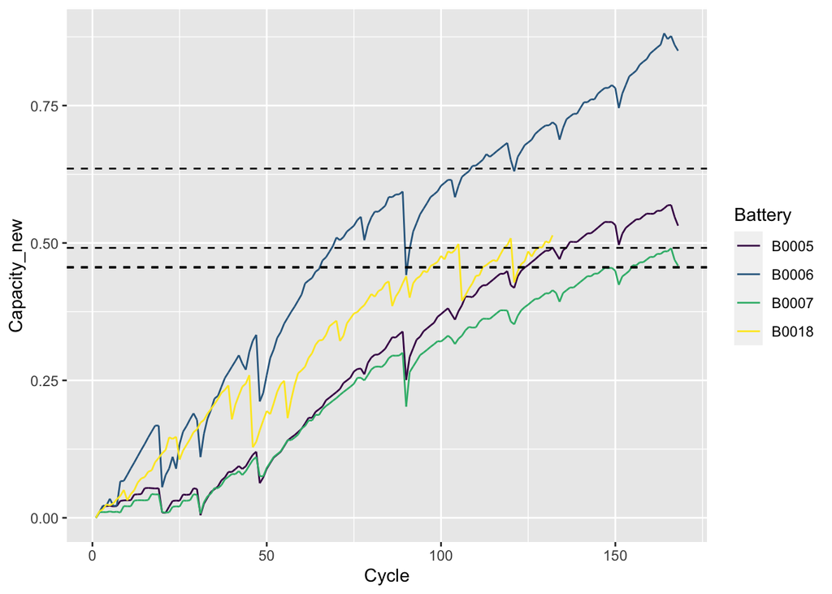

```r
max_battery = aggregate(liion_data$Capacity,by = list(liion_data$Battery),max)
max_battery$threshold = max_battery$x - 1.4

liion_data$Capacity_new = -liion_data$Capacity + rep(max_battery[,2],as.numeric(table(liion_data$Battery)))

liion_data %>%
  ggplot(aes(id_cycle,Capacity_new,color = Battery)) +
  geom_line() +
  scale_color_viridis(discrete = T) +
  xlab("Cycle") +
  #theme_bw() +
  #theme(panel.grid = element_blank()) + #添加失效阈值
  geom_hline(yintercept = max_battery$threshold[1],lty = 2) +
    geom_hline(yintercept = max_battery$threshold[2],lty = 2) +
      geom_hline(yintercept = max_battery$threshold[3],lty = 2) +
      geom_hline(yintercept = max_battery$threshold[4],lty = 2)
```

前面对数据进行了导入、处理以及可视化。接下来，使用经典的Gamma过程对其进行建模。

```r
liion_data %>%
  select(Capacity_new,Battery,id_cycle) %>%
  pivot_wider(
    names_from = "Battery",
    values_from = "Capacity_new",
    values_fn = mean) -> liion_new
```

```r
library(BB)
gamma_alpmle = function(x, data_unit, data, t){
    #x is alpha
    delta_t = diff(t)
    l = sum(delta_t*log(data_unit))-sum(t*log(data/(x*t)))-sum(delta_t*digamma(x*delta_t))
    return(l)
}

degradation = liion_new[-1,2:4]
group = ncol(degradation)
epoch = nrow(degradation)
increment = matrix(NA,epoch-1,group)
for (i in 1:group){
  dd = as.numeric(unlist(degradation[,i]))
  increment[,i] = abs(diff(dd))
}

# 这里跟初值影响很大
startx = 1.2
mle_re = dfsane(startx,gamma_alpmle,data_unit = increment, data = degradation, t = 1:epoch, control=list(maxit=2500,trace = FALSE))

mle_alp = mle_re$par
mle_beta = sum(increment)/(mle_alp*group*max(t))
mle_par = c(mle_alp,mle_beta)


#这里要先试出这个函数的上下界，并且增量不应该出现复数
# gamma_alpmle(1, data_unit = increment, data = degradation, t = 1:epoch)

# mle_re = uniroot(gamma_alpmle, data_unit = increment, data = degradation, t = 1:epoch, lower = 0.0000001, upper = 100, tol = 1e-15, maxiter = 10000)
#
# mle_alp = mle_re$root
# mle_beta = sum(increment)/(mle_alp*group*max(t))
# mle_par = c(mle_alp,mle_beta)
```

计算可靠度并绘图

```r
# 计算可靠度
gamma_R(t = 0.05, threshold = max_battery$threshold, par = mle_par)
```

```
## [1] 1 1 1 1
```

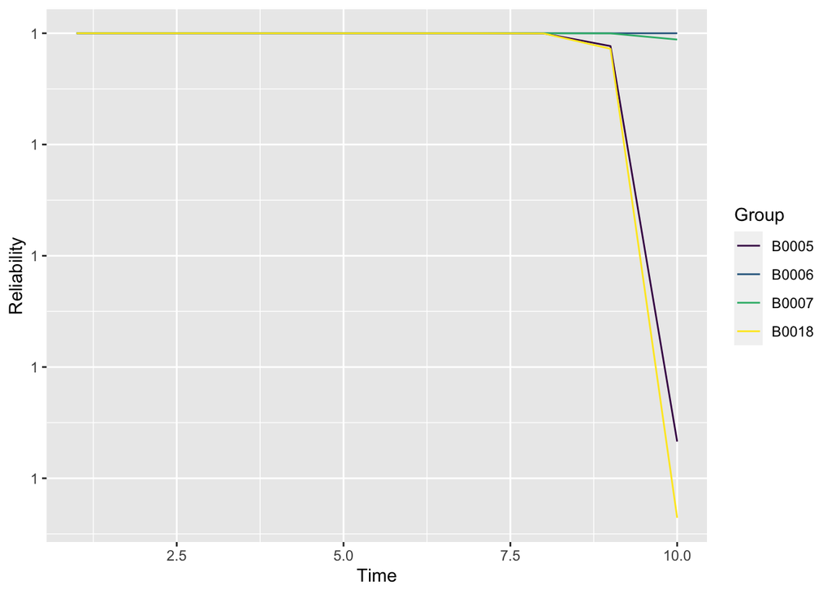

```r
time_region = 10
# 绘制四个电池的可靠度图
R_re = matrix(NA,time_region,4)
for(i in 1:4){
  R_re[,i] = gamma_R(t = 1:time_region, threshold = max_battery$threshold[i],par = mle_par)
}
R_re = as.data.frame(R_re)
R_re = cbind(1:time_region,R_re)
colnames(R_re) = c("time",max_battery[,1])
R_re %>% pivot_longer(max_battery[,1],
                       names_to = "Group",
                       values_to = "y") %>%
  ggplot(aes(time,y,color = Group,shape = Group)) +
  geom_line() +
  scale_color_viridis(discrete = T) +
  labs(x = "Time", y = "Reliability")
```